# Data Pre-Processing and Exploratory Analysis

### All coding, write up and analysis in this Jupyter Notebook was done by Awad Abdelhalim.

## Work prior to this notebook:

- Original crash dataset was obtained from VDot SmarterRoads portal.
  - The dataset consisted of two files of relevance: 1) Virginia_Crashes.dbf (1.24 GB) 2) Viriniga_Crashes.shp (22 MB).
- The raw data from the dbf file was converted into cvs format to compress information into 217 MBs.
- A brief statistical analysis was carried out on the file using SAS JMP software, results are briefly discussed in the project report.
- Inorder to reduce the size of the datafile prior to work in this notebook and upcoming notebooks, a few auxiliary attributes (crash ID, accident document number etc..) were removed, and all categorical information was label encoded into integers, the final Virginia_Crashes.csv file was also combined with location data for each accident extracted from the .shp file. Virginia_Crashes.csv is included with this report.
- CheatSheet.xlsx shows describtion of each attribute overall and label encoding for each attribute.

```python
#loading libraries to be used
import pandas as pd
import numpy as np
import os
from IPython.display import display

#Change directory below to wherever Crashes Database is saved if in different directory
#os.chdir('insert path to Virginia_Crashes.csv')

data=pd.read_csv('Virginia_Crashes.csv')
location=pd.read_csv('Virginia_Crashes_Locations.csv')

#display first 5 rows of the dataframe
#each row is an individual accident and columns are the different attributes for that specific accident

display(data[0:5])
```

|  | collision | weather | vehicles | light | surface | location | relation | hour | second | year | severity | ped_injury | ped_fatality | total_injury | total_fatality | work_zone | school_zone | route | district |
| --- | --- | --- | --- | --- | --- | --- | --- | --- | --- | --- | --- | --- | --- | --- | --- | --- | --- | --- | --- |
| 0 | 2 | 1 | 2 | 2 | 1 | 1 | 9 | 2:30 PM | 52200 | 2010 | 5 | 0 | 0 | 0 | 0 | 6 | 2 | 5 | 4 |
| 1 | 4 | 3 | 2 | 2 | 3 | 1 | 1 | 11:05 AM | 39900 | 2010 | 5 | 0 | 0 | 0 | 0 | 6 | 2 | 1 | 1 |
| 2 | 8 | 1 | 1 | 2 | 1 | 3 | 8 | 2:30 PM | 52200 | 2010 | 5 | 0 | 0 | 0 | 0 | 6 | 2 | 1 | 7 |
| 3 | 9 | 1 | 1 | 1 | 1 | 2 | 3 | 10:17 PM | 80220 | 2010 | 5 | 0 | 0 | 0 | 0 | 6 | 2 | 1 | 1 |
| 4 | 1 | 1 | 3 | 2 | 1 | 1 | 8 | 2:27 PM | 52020 | 2010 | 5 | 0 | 0 | 0 | 0 | 6 | 2 | 2 | 5 |

### One-Hot Encoding

Categorical attributes were declared as categorical to ensure they are not treated as continous attributes by methods used in this notebook. One-Hot encoding was used for all categorical attributes

```python
print('Original Features:\n', list(data.columns), '\n')

data['collision'] = data.collision.astype('category')
data['weather'] = data.weather.astype('category')
data['light'] = data.light.astype('category')
data['surface'] = data.surface.astype('category')
data['location'] = data.location.astype('category')
data['relation'] = data.relation.astype('category')
data['route'] = data.route.astype('category')
data['district'] = data.district.astype('category')
data['work_zone'] = data.work_zone.astype('category')
data['school_zone'] = data.school_zone.astype('category')
data['year'] = data.year.astype('category')
data['severity'] = data.severity.astype('category')

data_encoded = pd.get_dummies(data.drop('hour',1))
print('Features after One-Hot Encoding:\n', list(data_encoded.columns))

print('\n *Data shape: ',data.shape)
print('\n *Encoded shape: ', data_encoded.shape)
```

[output not shown]

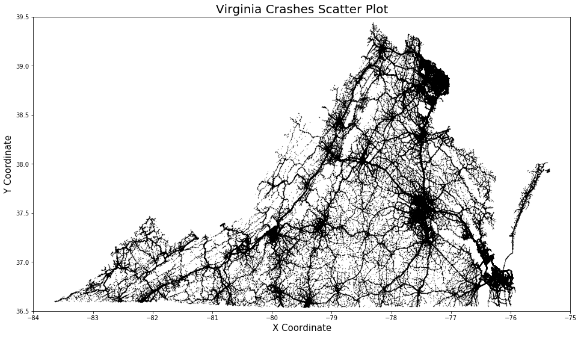

```python
#plotting geographical coordinates for first all accidents in the dataset
%matplotlib inline
import matplotlib.pyplot as plt

fig = plt.figure(figsize = (16,9))
ax = fig.add_subplot(1,1,1)
ax.set_xlabel('X Coordinate', fontsize = 15)
ax.set_ylabel('Y Coordinate', fontsize = 15)
ax.set_xlim(-84,-75)
ax.set_ylim(36.5,39.5)
ax.set_title('Virginia Crashes Scatter Plot', fontsize = 20)

x= location.X
y= location.Y
plt.scatter(x,y,s=0.05, c='k')

#accidents happen all over the state!
```

### Train-Test Split

- Data from the imported dataframe was extracted into numpy arrays, which were broken down into training and testing sets.
- X contains the attributes and Y contains the respective labels we're trying to predict which is crash severity.
- Majority of accidents in the dataset are severity 5: Property Damage accidents, the number of severity 1 (Fatal) and 3 (Pedestrian Fatal) is scarce, hence stratified sampling was used when breaking down the data to ensure we don't end up with training or test sets what do not include samples from such accidents.

```python
print('Number of accidents for each severity category: ')
display(data['severity'].value_counts())

print('Fraction of accidents for each severity category: ')
display(data['severity'].value_counts()/data.shape[0])
```

```
Number of accidents for each severity category:
```

```
5    503629
2    272869
4      8813
1      4024
3       579
Name: severity, dtype: int64
```

```
Fraction of accidents for each severity category:
```

```
5    0.637574
2    0.345441
4    0.011157
1    0.005094
3    0.000733
Name: severity, dtype: float64
```

```python
from sklearn.model_selection import train_test_split

#break data into attirbute table X and labels Y

x1 = pd.get_dummies(data.drop(['vehicles', 'hour', 'year','collision',
                'severity', 'ped_injury', 'ped_fatality', 'total_injury',
                'total_fatality', 'work_zone', 'school_zone'],1))

#change second into hour of day to reduce variance within the data
x1['second'] = round(x1['second']/3600,0)
x = x1.loc[:,:].values
y = data.loc[:,['severity']].values

#test train split
x_train, x_test, y_train, y_test = train_test_split(x, y, test_size=0.20, random_state=1, stratify=y)
```

```python
preaccident= data.drop(['vehicles', 'hour', 'year','collision',
                'severity', 'ped_injury', 'ped_fatality', 'total_injury',
                'total_fatality', 'work_zone', 'school_zone'],1)

print('The shape of preaccident data is: ', preaccident.shape)
display(preaccident.head(5))


print('\n \n After using one-hot encoded data and, the data used in analysis has shape of ', x1.shape)
x1.head(5)
```

```
The shape of preaccident data is:  (789914, 8)
```

|  | weather | light | surface | location | relation | second | route | district |
| --- | --- | --- | --- | --- | --- | --- | --- | --- |
| 0 | 1 | 2 | 1 | 1 | 9 | 52200 | 5 | 4 |
| 1 | 3 | 2 | 3 | 1 | 1 | 39900 | 1 | 1 |
| 2 | 1 | 2 | 1 | 3 | 8 | 52200 | 1 | 7 |
| 3 | 1 | 1 | 1 | 2 | 3 | 80220 | 1 | 1 |
| 4 | 1 | 2 | 1 | 1 | 8 | 52020 | 2 | 5 |

```
 After using one-hot encoded data and, the data used in analysis has shape of  (789914, 70)
```

|  | second | weather_1 | weather_2 | weather_3 | weather_4 | weather_5 | weather_6 | weather_7 | weather_8 | weather_9 | ... | district_1 | district_2 | district_3 | district_4 | district_5 | district_6 | district_7 | district_8 | district_9 | district_10 |
| --- | --- | --- | --- | --- | --- | --- | --- | --- | --- | --- | --- | --- | --- | --- | --- | --- | --- | --- | --- | --- | --- |
| 0 | 14.0 | 1 | 0 | 0 | 0 | 0 | 0 | 0 | 0 | 0 | ... | 0 | 0 | 0 | 1 | 0 | 0 | 0 | 0 | 0 | 0 |
| 1 | 11.0 | 0 | 0 | 1 | 0 | 0 | 0 | 0 | 0 | 0 | ... | 1 | 0 | 0 | 0 | 0 | 0 | 0 | 0 | 0 | 0 |
| 2 | 14.0 | 1 | 0 | 0 | 0 | 0 | 0 | 0 | 0 | 0 | ... | 0 | 0 | 0 | 0 | 0 | 0 | 1 | 0 | 0 | 0 |
| 3 | 22.0 | 1 | 0 | 0 | 0 | 0 | 0 | 0 | 0 | 0 | ... | 1 | 0 | 0 | 0 | 0 | 0 | 0 | 0 | 0 | 0 |
| 4 | 14.0 | 1 | 0 | 0 | 0 | 0 | 0 | 0 | 0 | 0 | ... | 0 | 0 | 0 | 0 | 1 | 0 | 0 | 0 | 0 | 0 |

5 rows × 70 columns

## Ensemble Method

### Random Forest Classifier

A random forest classifier was used to predict crash severity. Per Wikipedia, " Random forests or random decision forests are an ensemble learning method for classification, regression and other tasks, that operate by constructing a multitude of decision trees at training time and outputting the class that is the mode of the classes (classification) or mean prediction (regression) of the individual trees. Random decision forests correct for decision trees' habit of overfitting to their training set ".

#### Data was originally trained and tested on classifier with 100 estimators.

#### The number of estimators (sub-trees) was reduced to 20 in this notebook to reduce computational time for reviewer.

```python
import timeit
from sklearn.ensemble import RandomForestClassifier


classifier = RandomForestClassifier(n_estimators= 20, random_state=1)

# Timing training time
start= timeit.default_timer()
classifier.fit(x_train, y_train.ravel())
stop= timeit.default_timer()
print('Training Time: ', round((stop-start),2), ' seconds')

# Predicting the Test set results
y_pred = classifier.predict(x_test)
```

```
Training Time:  23.16  seconds
```

##### Checking the accuracy of the trained classifier

```python
from sklearn.metrics import accuracy_score

print('The classifier has an accuracy of: ', round(accuracy_score(y_test.ravel(), y_pred)*100,2), '%')
```

```
The classifier has an accuracy of:  61.74 %
```

### Confusion Matrix

To see where those misclassification errors are happening, we need to look at the confusion matrix for predicted vs actual labels.

```python
from sklearn.metrics import confusion_matrix

cm = confusion_matrix(y_test.ravel(), y_pred)
print(cm)
```

```
[[    1   184     0     0   620]
 [   27  7185     3    68 47291]
 [    0    12     0     0   104]
 [    0   195     1    16  1550]
 [   58 10204     9   119 90336]]
```

## Remove property damage crashes

Property damage crashes (Severity_5) are extremely unpredictable under any circumstances and make up a massive fraction of the data, yet they hinder prediction of other classes. In the following part of this notebook we remove those records as we are only interested in being able to predict crashes that lead to injuries and fatalities.

```python
data = data[data['severity']!=5]
data.dtypes
data ['severity'] = data['severity'].cat.remove_categories([5])
```

```python
print('Number of accidents for each severity category: ')
display(data['severity'].value_counts())

print('Fraction of accidents for each severity category: ')
display(data['severity'].value_counts()/data.shape[0])
```

```
Number of accidents for each severity category:
```

```
2    272869
4      8813
1      4024
3       579
Name: severity, dtype: int64
```

```
Fraction of accidents for each severity category:
```

```
2    0.953138
4    0.030784
1    0.014056
3    0.002022
Name: severity, dtype: float64
```

```python
x1 = pd.get_dummies(data.drop(['vehicles', 'hour', 'year', 'collision',
                'severity', 'ped_injury', 'ped_fatality', 'total_injury',
                'total_fatality', 'work_zone', 'school_zone'],1))
x1['second'] = round(x1['second']/3600,0)
x = x1.loc[:,:].values
y = data.loc[:,['severity']].values
x_train, x_test, y_train, y_test = train_test_split(x, y, test_size=0.20, random_state=1, stratify=y)
```

```python
classifier = RandomForestClassifier(n_estimators= 20, random_state=1)

start= timeit.default_timer()
classifier.fit(x_train, y_train.ravel())
stop= timeit.default_timer()
print('Training Time: ', round((stop-start),2), ' seconds')

# Predicting the Test set results
y_pred = classifier.predict(x_test)
```

```
Training Time:  5.51  seconds
```

```python
print('The classifier has an accuracy of: ', round(accuracy_score(y_test.ravel(), y_pred)*100,2), '%')

cm = confusion_matrix(y_test.ravel(), y_pred)
print(cm)
```

```
The classifier has an accuracy of:  94.88 %
[[    4   798     0     3]
 [   96 54288    10   180]
 [    0   114     1     1]
 [    4  1720     4    34]]
```

#### Accuracy is misguiding!

The classifier looked to have very high accuracy after removing the noisy property damage crashes. However, the reason for this turns out to be that it is misclassifying accident categories 1, 3 & 4 (respectively fatal, pedestrian fatal and pedestrian injury) crashes into severity category 2 (injury crashes). This is because as was shown above, the majority of the data is injury crashes and thus far we've given everything the same weight.

## Penalize misclassifying fatal crashes

```python
temp= data['severity'].value_counts()/data.shape[0]
temp= 1/temp
temp
```

```
2      1.049166
4     32.484398
1     71.144384
3    494.447323
Name: severity, dtype: float64
```

```python
w= {1:75,2:0.1,3:500,4:33}
```

```python
classifier = RandomForestClassifier(n_estimators= 20, random_state=1, class_weight=w)

start= timeit.default_timer()
classifier.fit(x_train, y_train.ravel())
stop= timeit.default_timer()
print('Training Time: ', round((stop-start),2), ' seconds')

# Predicting the Test set results
y_pred = classifier.predict(x_test)
```

```
Training Time:  5.18  seconds
```

```python
print('The classifier has an accuracy of: ', round(accuracy_score(y_test.ravel(), y_pred)*100,2), '%')

cm = confusion_matrix(y_test.ravel(), y_pred)
print(cm)
```

```
The classifier has an accuracy of:  48.55 %
[[  190   454    19   142]
 [ 8189 26758  2000 17627]
 [   15    56     8    37]
 [  147   673    98   844]]
```

## Stochastic Gradient Descent

We see that when giving each class an appropriate weight to make for the dataset bias, the classifier accuracy drops drastically. This is expected as accidents are extremely stochastic and aren't expected to be predicted easily.

Next, we use a Stochastic Gradient Descent classifier, which in addition to using the class weights we have used above also uses a loss function to penalize for misclassification. The SDG Classifier applied uses mini-batching (breaks dataset into epochs) and an adaptive learning rate function. While much better accuracy is expected using a customized loss function or optimizing class weights, this is out of scope of this project.

#### Data was originally trained and tested on classifier with 500 max_iterations.

#### The number of iterations was reduced to 20 in this notebook to reduce computational time for reviewer.

```python
from sklearn.linear_model import SGDClassifier

classifier = SGDClassifier(loss='modified_huber', penalty='l2', alpha=0.01, l1_ratio=0.15, fit_intercept=True, max_iter=20,
                           tol=None, shuffle=False, verbose=0, epsilon=0.1, random_state=1,
                           eta0= 0.03, learning_rate='invscaling', class_weight= w)

start= timeit.default_timer()
classifier.fit(x_train, y_train.ravel())
stop= timeit.default_timer()
print('Training Time: ', round((stop-start),2), ' seconds')

# Predicting the Test set results
y_pred = classifier.predict(x_test)
```

```
Training Time:  3.31  seconds
```

```python
print('The classifier has an accuracy of: ', round(accuracy_score(y_test.ravel(), y_pred)*100,2), '%')

cm = confusion_matrix(y_test.ravel(), y_pred)
print(cm)
```

```
The classifier has an accuracy of:  61.6 %
[[  372   289   130    14]
 [ 8429 34618  9269  2258]
 [    7    21    79     9]
 [  113   880   570   199]]
```

```python
for row in range(len(cm)):
    cm[row]= np.round(cm[row]/sum(cm[row])*100,2)
print('The percentage of prediction vs actual for each crash severity: \n', cm)
```

```
The percentage of prediction vs actual for each crash severity:
 [[46 35 16  1]
 [15 63 16  4]
 [ 6 18 68  7]
 [ 6 49 32 11]]
```

### Noticeable Improvement

The SDG Classification offers significant improvement over classification tree methods by using the loss function which penalizes misclassification. The basic SGD implemented managed to correctly predict almost 50% of fatal accidents and a stagerring 68% of Pedestrian Fatal Accidents, which is very high considering the highly stochastic nature of the data.

#### Much better results are expected when optimizing this method for the dataset.

## Concluding Remarks

The classification models explored above show potential for predicting accident severity based only on pre-accident conditions. In the following notebooks (and sections of the report), we explore dividing the multi-class classification task above into multiple binary classification problems using LightGradientBoosting. We also explore completely ignoring the severity and testing the dataset for association rules between different pre-accident conditions that may cause more accidents.

# Data Visualization

#### In this section of the notebook, we explore innovative ways to analyze the dataset through visualization.

#### Two techniques were implemented:

- Applying Principal Component Analyses to the dataset and reducing the attribute data to 3 dimensions which allows visualzing. The resulting 3D plot shows that certain accident severities seem to cluster together, but 3 components is definitely not enough to explain all the variance.
- Next, KMeans clustering was applied to the geographical coordinates of the dataset. Virginia Department of Transportation (VDOT) currenlty operates through 9 different subdivisions (Districts), the purpose of this analyses was to visualize the crash clusters and test if that maps to district boundaries.

## PLOT PCA

```python
from sklearn.decomposition import PCA

x1 = data.drop(['vehicles', 'hour', 'year','collision',
                'severity', 'ped_injury', 'ped_fatality', 'total_injury',
                'total_fatality', 'work_zone', 'school_zone'],1)

#change second into hour of day to reduce variance within the data
x1['second'] = round(x1['second']/3600,0)
x = x1.loc[:,:].values
y = data.loc[:,['severity']].values
```

```python
from sklearn.preprocessing import StandardScaler

sc= StandardScaler()
x= sc.fit_transform(x)
```

```python
pca = PCA()
principalComponents = pca.fit_transform(x)
```

```python
ex= pca.explained_variance_ratio_
ex
```

```
array([0.18609526, 0.15449894, 0.13872894, 0.13255072, 0.12267337,
       0.1034398 , 0.08975723, 0.07225573])
```

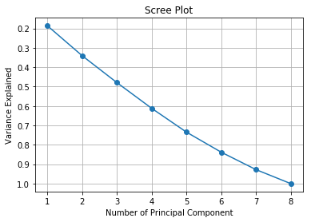

```python
var= []
total= 0
for i in range(len(ex)):
    total+= ex[i]
    var.append(total)

plt.plot(range(1,9), var, 'o-')
plt.title('Scree Plot')
plt.xlabel('Number of Principal Component')
plt.ylabel('Variance Explained')
plt.gca().invert_yaxis()
plt.grid()
```

```python
pca = PCA(n_components=3)
principalComponents = pca.fit_transform(x)
principalDf = pd.DataFrame(data = principalComponents
             , columns = ['principal component 1', 'principal component 2', 'principal component 3'])
principalDf.head(5)
```

|  | principal component 1 | principal component 2 | principal component 3 |
| --- | --- | --- | --- |
| 0 | -0.519971 | 0.418497 | 0.110998 |
| 1 | -0.508943 | 0.101676 | 1.617210 |
| 2 | -0.281635 | -0.501175 | -1.297875 |
| 3 | -0.314295 | 0.571954 | -1.011585 |
| 4 | 3.836883 | 1.626684 | 0.654948 |

```python
#finalDf = principalDf.assign(severity= data['severity'])
finalDf = pd.concat([principalDf, data['severity'].reset_index(drop=True)], axis = 1)
finalDf.head(5)
```

|  | principal component 1 | principal component 2 | principal component 3 | severity |
| --- | --- | --- | --- | --- |
| 0 | -0.519971 | 0.418497 | 0.110998 | 2 |
| 1 | -0.508943 | 0.101676 | 1.617210 | 3 |
| 2 | -0.281635 | -0.501175 | -1.297875 | 2 |
| 3 | -0.314295 | 0.571954 | -1.011585 | 1 |
| 4 | 3.836883 | 1.626684 | 0.654948 | 1 |

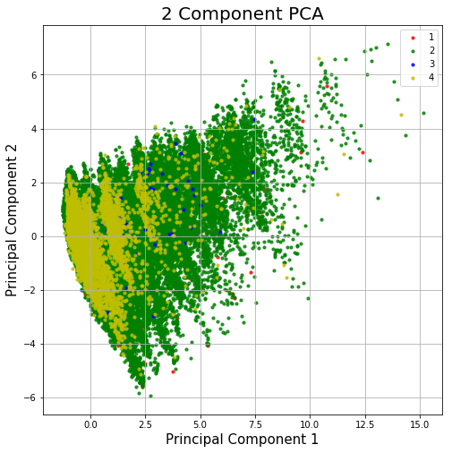

```python
fig = plt.figure(figsize = (8,8))
ax = fig.add_subplot(1,1,1)
ax.set_xlabel('Principal Component 1', fontsize = 15)
ax.set_ylabel('Principal Component 2', fontsize = 15)
ax.set_title('2 Component PCA', fontsize = 20)


severity = [1, 2, 3, 4]
colors = ['r', 'g', 'b', 'y']

for sev, color in zip(severity,colors):
    indicesToKeep = finalDf['severity'] == sev
    ax.scatter(finalDf.loc[indicesToKeep, 'principal component 1']
               , finalDf.loc[indicesToKeep, 'principal component 2']
               , c = color
               , s = 10
               , alpha = 0.8)
ax.legend(severity)
ax.grid()
```

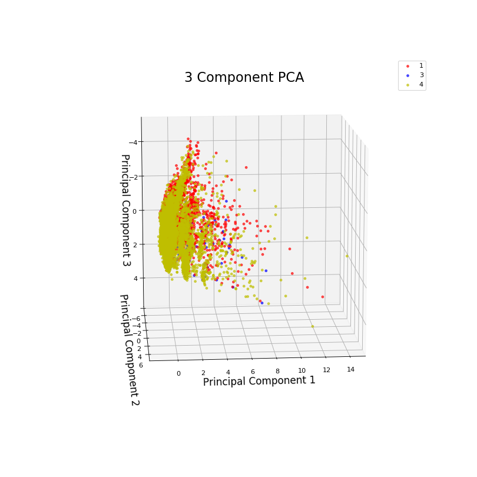

```python
# You may need to re-run this cell multiple times to get 3-D interactive viewer.
# Depends on your GPU

from mpl_toolkits.mplot3d import Axes3D
%matplotlib notebook

fig = plt.figure(figsize = (10,10))
ax = fig.add_subplot(111, projection='3d')
ax.set_xlabel('Principal Component 1', fontsize = 15)
ax.set_ylabel('Principal Component 2', fontsize = 15)
ax.set_zlabel('Principal Component 3', fontsize = 15)

ax.set_title('3 Component PCA', fontsize = 20)


severity = [1, 3, 4]
colors = ['r', 'b', 'y']

for sev, color in zip(severity,colors):
    indicesToKeep = finalDf['severity'] == sev
    ax.scatter(finalDf.loc[indicesToKeep, 'principal component 1']
               , finalDf.loc[indicesToKeep, 'principal component 2']
               , finalDf.loc[indicesToKeep, 'principal component 3']
               , c = color
               , s = 10
               , alpha = 0.65)
ax.legend(severity)
ax.grid()
```